# Explication de modèles NLP

Tous les modèles d'apprentissage automatique qui opèrent dans des dimensions supérieures à ce qui peut être directement visualisé par l'esprit humain peuvent être qualifiés de modèles boîte noire, ce qui affecte l'interprétabilité des modèles. En particulier dans le domaine du traitement du langage naturel (NLP), il est toujours le cas que les dimensions des caractéristiques sont très grandes, ce qui rend beaucoup plus compliquée l'explication de l'importance des caractéristiques.

### 1- Importation des bibliothèques

```python
from tensorflow.keras import layers
from tensorflow import keras
import tensorflow as tf

from sklearn.model_selection import train_test_split
from ast import literal_eval

import matplotlib.pyplot as plt
import pandas as pd
import numpy as np
import os
import tensorflow as tf
```

### 2- Chargement et préparation des données

```python
df=pd.read_csv('EFREI - LIPSTIP - 50k elements EPO.csv')
df.info()
```

```
<class 'pandas.core.frame.DataFrame'>
RangeIndex: 50000 entries, 0 to 49999
Data columns (total 8 columns):
 #   Column                 Non-Null Count  Dtype
---  ------                 --------------  -----
 0   Numéro d'application   50000 non-null  int64
 1   Date d'application     50000 non-null  object
 2   Numero de publication  50000 non-null  int64
 3   date de publication    50000 non-null  object
 4   CPC                    50000 non-null  object
 5   IPC                    50000 non-null  object
 6   claim                  50000 non-null  object
 7   description            50000 non-null  object
dtypes: int64(2), object(6)
memory usage: 3.1+ MB
```

```python
df.shape
```

```
(50000, 8)
```

```python
df.head()
```

|  | Numéro d'application | Date d'application | Numero de publication | date de publication | CPC | IPC | claim | description |
| --- | --- | --- | --- | --- | --- | --- | --- | --- |
| 0 | 17167919 | 2017-04-25 | 3264223 | 2018-01-03 | ['B23K26-361', 'H04M1-0266', 'B23K26-402', 'G0... | ['C08J7-04', 'H04M1-02', 'G06F1-16', 'B23K26-3... | <!-- EPO <DP n="18"> --><claim id="c-en-0001" ... | <!-- EPO <DP n="1"> --><p id="p0001" num="0001... |
| 1 | 17166775 | 2017-04-18 | 3235458 | 2017-10-25 | ['A61B17-68', 'A61B17-888', 'A61B17-8685', 'A6... | ['A61B17-88', 'A61B17-68', 'A61B17-86'] | <!-- EPO <DP n="20"> --><claim id="c-en-0001" ... | <!-- EPO <DP n="1"> --><heading id="h0001">FIE... |
| 2 | 17166069 | 2017-04-11 | 3249094 | 2017-11-29 | ['D06F58-206', 'D06F58-20'] | ['D06F58-20', 'D06F58-02'] | <!-- EPO <DP n="22"> --><claim id="c-en-0001" ... | <!-- EPO <DP n="1"> --><heading id="h0001"><b>... |
| 3 | 18771363 | 2018-03-05 | 3605724 | 2020-02-05 | ['H01P1-2138', 'H01P5-107', 'H01P1-2088', 'H01... | ['H01P3-12', 'H01P1-213', 'H01P5-107'] | <!-- EPO <DP n="62"> --><claim id="c-en-0001" ... | <!-- EPO <DP n="1"> --><heading id="h0001">Tec... |
| 4 | 19881950 | 2019-11-01 | 3713245 | 2020-09-23 | ['H04N21-4345', 'H04N21-4821', 'H04N21-4316'] | ['H04N21-482', 'H04N21-262'] | <!-- EPO <DP n="14"> --><claim id="c-en-0001" ... | <!-- EPO <DP n="1"> --><p id="p0001" num="0001... |

```python
df=df.drop(["Numero de publication","date de publication","IPC","Numéro d'application", "Date d'application"],axis=1)
```

```python
df.isnull().sum()
```

```
CPC            0
claim          0
description    0
dtype: int64
```

La base de données ne contient aucune informations manquante

```python
total_duplicate = sum(df.duplicated())
print(f"There are {total_duplicate} duplicate data.")
```

```
There are 0 duplicate data.
```

Les données sont mélangées pour s'assurer qu'elles sont réparties aléatoirement.

```python
from sklearn.utils import shuffle
df = shuffle(df,random_state=101)
```

On utilise les 20 000 premières lignes pour l'entraînement.

```python
df = df[:20000]
print(f"There are {len(df)} rows in the dataset.")
```

```
There are 20000 rows in the dataset.
```

Création d'une nouvelle colonne pour les sous-classes CPC et conversion en liste

### 3- Préparation des labels et nettoyage des données

Les codes CPC sont extraits et transformés en liste, puis tronqués à quatre caractères, et stockés dans une nouvelle colonne CPC_tronc.

```python
from ast import literal_eval
labels = df["CPC"].str.split(",")
```

```python
labels = df["CPC"].apply(literal_eval)
print(labels.values[:1])
```

```
[list(['C02F1-444', 'B01D63-02', 'B01D65-02', 'B01D63-04', 'B01D63-033', 'B01D2321-185'])]
```

```python
labels
```

```
18447    [C02F1-444, B01D63-02, B01D65-02, B01D63-04, B...
17768    [G01R31-2642, G01R31-42, G01R31-2608, G01R31-2...
45879    [H04L5-14, H04L5-1469, H04L5-1461, H04B3-32, H...
16972    [H04N1-23, H04N1-387, G03G15-36, G03G15-5095, ...
12165                                        [G06Q30-0601]
                               ...
23163                                        [E21B17-1035]
33167    [G10K15-00, H04S7-301, H04R1-403, H04R3-12, H0...
10987    [B41J2-14233, B41J2-161, B41J2-1632, B41J2-162...
27639    [B33Y30-00, B22F3-24, B22F12-70, B33Y40-20, B2...
41020                 [B66B5-0037, B66B5-0031, B66B5-0025]
Name: CPC, Length: 20000, dtype: object
```

```python
def tronquer_codes_cpc(codes):
    return [[code[:4] for code in liste_codes ]  for liste_codes in codes]

moi=tronquer_codes_cpc(labels)
moi
```

```
[['C02F', 'B01D', 'B01D', 'B01D', 'B01D', 'B01D'],
 ['G01R', 'G01R', 'G01R', 'G01R'],
 ['H04L', 'H04L', 'H04L', 'H04B', 'H04L', 'H04L', 'H04L', 'H04L'],
 ['H04N',
  'H04N',
  'G03G',
  'G03G',
  'G03G',
  'H04N',
  'H04N',
  'G06F',
  'G06F',
  'G03G',
  'G06F',
  'G03G',
  'G06F'],
 ['G06Q'],
 ['G02B', 'G02B', 'G02B'],
 ['H01L', 'H01L', 'H01L', 'H01L', 'H01L', 'H01L', 'H01L'],
 ['B29D', 'B29D', 'B29K', 'B29K'],
 ['C23C', 'C23C', 'C23C', 'H01J', 'H01J', 'H01J', 'H01J', 'H01J'],
 ['H02G', 'H02G', 'H02G'],
 ['C09D',
  'C22C',
  'C09D',
  'C09D',
  'C09D',
  'C23C',
  'C22C',
  'C09D',
  'C09D',
  'C23C',
  'C08G',
  'C23C',
  'B05D',
  'C08G',
  'B32B',
  'B32B',
  'B05D',
  'B05D',
```

[output cut: 3198 more lines]

```
  'H05K',
  'H05K',
  'H05K'],
 ['H02J', 'H02J', 'Y04S', 'G01R'],
 ['A61P', 'A61K'],
 ['H04L', 'H04L', 'H04L', 'G06F', 'H04L', 'H04L'],
 ['H04N', 'H04N', 'H04M', 'H04N', 'H04M', 'H04M', 'H04N'],
 ['H01M', 'H01M', 'Y02E'],
 ['G06V', 'G06V', 'G06V', 'G06F'],
 ['H04L', 'H04W', 'H04W', 'H04W'],
 ['H04N', 'H04N', 'H04N', 'H04N', 'H04N', 'H04N', 'H04N', 'H04N'],
 ['D01F', 'D01F', 'D01F'],
 ['B62K', 'B62K'],
 ['G06T', 'G01S', 'G01S', 'G06V', 'G06V', 'G01S'],
 ...]
```

```python
df["CPC_tronc"]=moi
```

```python
print(df["CPC_tronc"])
```

```
18447                 [C02F, B01D, B01D, B01D, B01D, B01D]
17768                             [G01R, G01R, G01R, G01R]
45879     [H04L, H04L, H04L, H04B, H04L, H04L, H04L, H04L]
16972    [H04N, H04N, G03G, G03G, G03G, H04N, H04N, G06...
12165                                               [G06Q]
                               ...
23163                                               [E21B]
33167    [G10K, H04S, H04R, H04R, H04R, H04R, H04S, H04...
10987           [B41J, B41J, B41J, B41J, B41J, B41J, B41J]
27639    [B33Y, B22F, B22F, B33Y, B22F, B22F, B22F, B22...
41020                                   [B66B, B66B, B66B]
Name: CPC_tronc, Length: 20000, dtype: object
```

### Nettoyage du texte

Décoder le texte HTML en texte brut en utilisant BeautifulSoup.

Convertir le texte en minuscules.

Remplacer certains symboles spécifiques par des espaces.

Supprimer certains symboles considérés comme indésirables.

Supprimer les stopwords

```python
from bs4 import BeautifulSoup
from nltk.corpus import stopwords
import re

REPLACE_BY_SPACE_RE = re.compile('[/(){}\[\]\|@,;]')
BAD_SYMBOLS_RE = re.compile('[^0-9a-z #+_]')
STOPWORDS = set(stopwords.words('english'))

def clean_text(text):
    text = BeautifulSoup(text, "lxml").text # Décode le HTML en texte brut
    text = text.lower() # Convertit en minuscules
    text = REPLACE_BY_SPACE_RE.sub(' ', text) # Remplace certains symboles par des espaces
    text = BAD_SYMBOLS_RE.sub('', text) # Supprime certains symboles indésirables
    text = ' '.join(word for word in text.split() if word not in STOPWORDS) # Supprime les stopwords
    return text
```

```python
df['description'] = df['description'].apply(clean_text)
#print(df['description'].iloc[0])
```

### 4- Division du jeu de données

```python
test_split = 0.2

train_df, test_df = train_test_split(
    df,
    test_size=test_split
)

val_df = test_df.sample(frac=0.5)
test_df.drop(val_df.index, inplace=True)
```

```python
train_df.head()
```

|  | CPC | claim | description | CPC_tronc |
| --- | --- | --- | --- | --- |
| 40244 | ['G06F21-44', 'G06F21-12', 'G06F16-22', 'G06F2... | <!-- EPO <DP n="54"> --><claim id="c-en-0001" ... | field inventionembodiments relate generally pr... | [G06F, G06F, G06F, G06F, G06F, G06F, G06F, G06... |
| 15459 | ['C07D417-06', 'C07D417-12', 'C07D413-12', 'C0... | <!-- EPO <DP n="309"> --><claim id="c-en-0001"... | technical fieldthe present invention relates a... | [C07D, C07D, C07D, C07D, C07D, C07D, C07D, C07... |
| 25744 | ['B05B1-14', 'B65D83-285', 'B65D83-22', 'B65D8... | <!-- EPO <DP n="19"> --><claim id="c-en-0001" ... | technical fieldthe present disclosure relates ... | [B05B, B65D, B65D, B65D, B05B] |
| 31347 | ['B65D5-6611'] | <!-- EPO <DP n="16"> --><claim id="c-en-0001" ... | technical field present invention relates fast... | [B65D] |
| 18066 | ['F16F9-512', 'F16F3-02'] | <!-- EPO <DP n="22"> --><claim id="c-en-0001" ... | technical fieldthe invention relates valve arr... | [F16F, F16F] |

```python
val_df.head()
```

|  | CPC | claim | description | CPC_tronc |
| --- | --- | --- | --- | --- |
| 2817 | ['G07F9-009', 'G07F9-002', 'G06Q30-06', 'G07F9... | <!-- EPO <DP n="110"> --><claim id="c-en-0001"... | technical fieldthe present invention relates s... | [G07F, G07F, G06Q, G07F, G07F, G06Q, G07F, G07... |
| 33260 | ['F01D11-005', 'F01D11-08', 'F01D25-246', 'F16... | <!-- EPO <DP n="11"> --><claim id="c-en-0001" ... | background inventionthe invention relates pist... | [F01D, F01D, F01D, F16J, F05D, F05D, F05D, F05... |
| 24604 | ['G01N21-8851', 'G01N21-8806', 'G01N2021-8829'] | <!-- EPO <DP n="16"> --><claim id="c-en-0001" ... | backgroundtechnical fieldembodiments present d... | [G01N, G01N, G01N] |
| 14469 | ['H05B45-20', 'H05B45-30', 'H05B45-52', 'H05B4... | <!-- EPO <DP n="21"> --><claim id="c-en-0001" ... | backgroundthe present invention relates detect... | [H05B, H05B, H05B, H05B] |
| 40069 | ['C09B67-0051', 'C09B45-16', 'D06P1-39', 'D06P... | <!-- EPO <DP n="29"> --><claim id="c-en-0001" ... | present application based claims priority jp a... | [C09B, C09B, D06P, D06P, D06P, D06P] |

```python
print(f"Number of rows in training set: {len(train_df)}")
print(f"Number of rows in validation set: {len(val_df)}")
print(f"Number of rows in test set: {len(test_df)}")
```

```
Number of rows in training set: 16000
Number of rows in validation set: 2000
Number of rows in test set: 2000
```

### 5- Préparation des labels pour le modèle

Dans cette étape, nous allons préparer les étiquettes pour l'entraînement en utilisant la couche StringLookup de TensorFlow, qui convertit les labels sous forme de texte en encodages numériques (multi-hot) que le modèle peut utiliser.

Multi-hot : Chaque label est représenté par un vecteur binaire où chaque dimension correspond à un label possible. Si un document est associé à plusieurs labels, ces labels sont tous activés dans le vecteur multi-hot. Cela permet au modèle de traiter des problèmes de classification multi-label, où un échantillon peut appartenir à plusieurs catégories simultanément.

On extrait le vocabulaire (les labels uniques) de la couche StringLookup. Ensuite, on nettoie les entrées du vocabulaire en supprimant les espaces et les caractères superflus pour obtenir une liste propre de labels uniques.

La fonction invert_multi_hot permet de convertir un vecteur multi-hot encodé en une liste de labels lisibles, facilitant ainsi l'interprétation des résultats du modèle.

```python
Subclass_labels = tf.ragged.constant(train_df["CPC_tronc"].values)
lookup = tf.keras.layers.StringLookup(output_mode="multi_hot")
lookup.adapt(Subclass_labels)
vocab = lookup.get_vocabulary()
cleaned_vocab = [entry.strip().strip("[]'") for entry in vocab if entry.strip()]


def invert_multi_hot(encoded_labels):
    """Reverse a single multi-hot encoded label to a tuple of vocab Subclass_labels."""
    hot_indices = np.argwhere(encoded_labels == 1.0)[..., 0]
    return np.take(cleaned_vocab, hot_indices)


print("Vocabulary:\n")
#print(cleaned_vocab)
```

```
Vocabulary:
```

```python
print(len(cleaned_vocab))
```

```
596
```

Un exemple pour montrer comment une étiquette de sous-classe est extraite d'un DataFrame, puis transformée en une représentation binarisée utilisant la couche lookup.

```python
sample_label = train_df["CPC_tronc"].iloc[0]
print(f"Original label: {sample_label}")

label_binarized = lookup([sample_label])
print(f"Label-binarized representation: {label_binarized}")
```

```
Original label: ['G06F', 'G06F', 'G06F', 'G06F', 'G06F', 'G06F', 'G06F', 'G06F', 'G06F', 'G06F']
Label-binarized representation: [[0 0 0 0 0 1 0 0 0 0 0 0 0 0 0 0 0 0 0 0 0 0 0 0 0 0 0 0 0 0 0 0 0 0 0 0
  0 0 0 0 0 0 0 0 0 0 0 0 0 0 0 0 0 0 0 0 0 0 0 0 0 0 0 0 0 0 0 0 0 0 0 0
  0 0 0 0 0 0 0 0 0 0 0 0 0 0 0 0 0 0 0 0 0 0 0 0 0 0 0 0 0 0 0 0 0 0 0 0
  0 0 0 0 0 0 0 0 0 0 0 0 0 0 0 0 0 0 0 0 0 0 0 0 0 0 0 0 0 0 0 0 0 0 0 0
  0 0 0 0 0 0 0 0 0 0 0 0 0 0 0 0 0 0 0 0 0 0 0 0 0 0 0 0 0 0 0 0 0 0 0 0
  0 0 0 0 0 0 0 0 0 0 0 0 0 0 0 0 0 0 0 0 0 0 0 0 0 0 0 0 0 0 0 0 0 0 0 0
  0 0 0 0 0 0 0 0 0 0 0 0 0 0 0 0 0 0 0 0 0 0 0 0 0 0 0 0 0 0 0 0 0 0 0 0
  0 0 0 0 0 0 0 0 0 0 0 0 0 0 0 0 0 0 0 0 0 0 0 0 0 0 0 0 0 0 0 0 0 0 0 0
  0 0 0 0 0 0 0 0 0 0 0 0 0 0 0 0 0 0 0 0 0 0 0 0 0 0 0 0 0 0 0 0 0 0 0 0
  0 0 0 0 0 0 0 0 0 0 0 0 0 0 0 0 0 0 0 0 0 0 0 0 0 0 0 0 0 0 0 0 0 0 0 0
  0 0 0 0 0 0 0 0 0 0 0 0 0 0 0 0 0 0 0 0 0 0 0 0 0 0 0 0 0 0 0 0 0 0 0 0
  0 0 0 0 0 0 0 0 0 0 0 0 0 0 0 0 0 0 0 0 0 0 0 0 0 0 0 0 0 0 0 0 0 0 0 0
  0 0 0 0 0 0 0 0 0 0 0 0 0 0 0 0 0 0 0 0 0 0 0 0 0 0 0 0 0 0 0 0 0 0 0 0
  0 0 0 0 0 0 0 0 0 0 0 0 0 0 0 0 0 0 0 0 0 0 0 0 0 0 0 0 0 0 0 0 0 0 0 0
  0 0 0 0 0 0 0 0 0 0 0 0 0 0 0 0 0 0 0 0 0 0 0 0 0 0 0 0 0 0 0 0 0 0 0 0
  0 0 0 0 0 0 0 0 0 0 0 0 0 0 0 0 0 0 0 0 0 0 0 0 0 0 0 0 0 0 0 0 0 0 0 0
  0 0 0 0 0 0 0 0 0 0 0 0 0 0 0 0 0 0 0 0]]
```

### 6- Préparation des jeux de données pour TensorFlow

Nous devons préparer les textes en assurant qu'ils ont une longueur unifiée pour pouvoir les passer dans le modèle. Pour cela, nous allons:Définir la longueur maximale de séquence et le batch size, puis la fonction unify_text_length sépare le texte en mots, calcule sa longueur et la quantité de padding nécessaire

Uniformiser la longueur des séquences de texte pour qu'elles aient toutes la même longueur, facilitant ainsi leur traitement par le modèle de machine learning. En effet, pour qu'un batch de données puisse être traité efficacement par un modèle, chaque exemple dans le batch doit avoir la même forme.

```python
max_seqlen = 400
batch_size = 32
padding_token = "<pad>"
auto = tf.data.AUTOTUNE

def unify_text_length(text, label):
    word_splits = tf.strings.split(text, sep=" ")
    sequence_length = tf.shape(word_splits)[0]

    padding_amount = max_seqlen - sequence_length

    if padding_amount > 0:
        unified_text = tf.pad([text], [[0, padding_amount]], constant_values=padding_token)
        unified_text = tf.strings.reduce_join(unified_text, separator="")
    else:
        unified_text = tf.strings.reduce_join(word_splits[:max_seqlen], separator=" ")

    return tf.expand_dims(unified_text, -1), label
```

La fonction make_dataset crée un dataset TensorFlow prêt pour l'entraînement, la validation et le test en transformant les textes et les labels en un format que le modèle peut traiter efficacement.

```python
def make_dataset(dataframe, is_train=True):
    labels = tf.ragged.constant(dataframe["CPC_tronc"].values)
    label_binarized = lookup(labels).numpy()
    dataset = tf.data.Dataset.from_tensor_slices(
        (dataframe["description"].values, label_binarized)
    )
    dataset = dataset.shuffle(batch_size * 10) if is_train else dataset
    dataset = dataset.map(unify_text_length, num_parallel_calls=auto).cache()
    return dataset.batch(batch_size)
```

```python
train_dataset = make_dataset(train_df, is_train=True)
validation_dataset = make_dataset(val_df, is_train=False)
test_dataset = make_dataset(test_df, is_train=False)
```

```python
train_dataset
```

```
<_BatchDataset element_spec=(TensorSpec(shape=(None, 1), dtype=tf.string, name=None), TensorSpec(shape=(None, 596), dtype=tf.int64, name=None))>
```

Chaque élément de train_dataset est un tuple contenant deux éléments : un tenseur représentant un texte (tf.Tensor de type string). et un tenseur représentant les labels encodés en multi-hot (tf.Tensor de type int64).

#### Quelques exemples de textes et leurs labels correspondants après le traitement

```python
text_batch, label_batch = next(iter(train_dataset))

for i, text in enumerate(text_batch[:3]):
    label = label_batch[i].numpy()[None, ...]
    print(f"description: {text[0]}")
    print(f"Label(s): {invert_multi_hot(label[0])}")
    print(" ")
```

```
description: b'fieldthe present disclosure relates information processing apparatus information processing method programbackgroundin recent years fundamental technology streaming service internet moving picture experts group phasedynamic adaptive streaming http mpegdash becoming common see example …
Label(s): ['H04N']

description: b'technical fieldthe present application refers catalyst preparation method application reforming carbon dioxide methane syngas belonging field chemical engineeringbackgroundcoal petroleum natural gas three major fossil energy sources china coal resources abundant recent years pollution…
Label(s): ['B01J' 'C01B']

description: b'technical fieldthis disclosure relates work area determination system autonomous traveling work machine autonomous traveling work machine work area determination programbackground discussionin recent years growing popularity autonomous traveling work machine automatically effects main…
Label(s): ['G05D' 'A01D']
```

### 7- Vectorisation des textes

Cette partie du code calcule la taille maximale du vocabulaire basé sur la longueur des textes dans le dataframe d'entraînement (train_df) et ressort la taille du plus long texte

```python
train_df["total_words"] = train_df["description"].str.split().str.len()
vocabulary_size = train_df["total_words"].max()
print(f"Vocabulary size: {vocabulary_size}")
```

```
Vocabulary size: 162662
```

Une couche TextVectorization de Keras est utilisée pour convertir les textes en vecteurs de TF-IDF. map : Applique une fonction à chaque élément du dataset. Ici, la fonction lambda applique text_vectorizer pour transformer les textes en vecteurs de TF-IDF.

Utiliser des n-grammes et TF-IDF permet de capturer des informations importantes sur la fréquence des mots et leur importance relative dans le corpus, ce qui peut améliorer la performance du modèle.

```python
text_vectorizer = layers.TextVectorization(
    max_tokens=vocabulary_size, ngrams=2, output_mode="tf_idf"
)

with tf.device("/CPU:0"):
    text_vectorizer.adapt(train_dataset.map(lambda text, label: text))

train_dataset = train_dataset.map(
    lambda text, label: (text_vectorizer(text), label), num_parallel_calls=auto
).prefetch(auto)
validation_dataset = validation_dataset.map(
    lambda text, label: (text_vectorizer(text), label), num_parallel_calls=auto
).prefetch(auto)
test_dataset = test_dataset.map(
    lambda text, label: (text_vectorizer(text), label), num_parallel_calls=auto
).prefetch(auto)
```

### 8- Définition et compilation du modèle

Le modèle de deep learning utilisé dans votre programme est un réseau de neurones multicouche (MLP pour Multi-Layer Perceptron). Lorsque des données sont introduites dans le modèle, elles passent à travers chaque couche. Chaque couche applique une transformation linéaire suivie d'une fonction d'activation non linéaire (dans ce cas, "relu" pour les couches cachées et "sigmoid" pour la couche de sortie).

make_model() : Cette fonction crée et retourne un modèle séquentiel (Sequential) de Keras, qui est une séquence linéaire de couches.Elles ajoute 3 couches denses.

Première couche dense : Composée de 512 neurones avec une fonction d'activation ReLU. Cela permet au modèle d'apprendre des représentations non linéaires à partir des données.

Deuxième couche dense : Composée de 256 neurones avec une fonction d'activation ReLU. Cette couche réduit progressivement la dimensionnalité des représentations apprises par le modèle.

Troisième couche dense : C'est la couche de sortie du modèle. Le nombre de neurones correspond à la taille du vocabulaire déterminé par lookup.vocabulary_size(), et l'activation "sigmoid" est utilisée pour une classification multi-label où chaque neurone de sortie prédit une probabilité indépendante d'appartenance à une classe.

```python
def make_model():
    shallow_mlp_model = keras.Sequential(
        [
            layers.Dense(512, activation="relu"),
            layers.Dense(256, activation="relu"),
            layers.Dense(lookup.vocabulary_size(), activation="sigmoid"),
        ]
    )
    return shallow_mlp_model
```

recall_m et precision_m: Calculent respectvement le rappel et la précision en utilisant la formule standard basée sur les vrais positifs et les faux négatifs.

f1_m : Calcule la F1-score en utilisant la formule harmonique de la précision et du rappel

```python
import tensorflow.keras.backend as K

def recall_m(y_true, y_pred):
    y_true = tf.cast(y_true, tf.float32)
    y_pred = tf.cast(y_pred, tf.float32)
    true_positives = K.sum(K.round(K.clip(y_true * y_pred, 0, 1)))
    possible_positives = K.sum(K.round(K.clip(y_true, 0, 1)))
    recall = true_positives / (possible_positives + K.epsilon())
    return recall

def precision_m(y_true, y_pred):
    y_true = tf.cast(y_true, tf.float32)
    y_pred = tf.cast(y_pred, tf.float32)
    true_positives = K.sum(K.round(K.clip(y_true * y_pred, 0, 1)))
    predicted_positives = K.sum(K.round(K.clip(y_pred, 0, 1)))
    precision = true_positives / (predicted_positives + K.epsilon())
    return precision

def f1_m(y_true, y_pred):
    y_true = tf.cast(y_true, tf.float32)
    y_pred = tf.cast(y_pred, tf.float32)
    precision = precision_m(y_true, y_pred)
    recall = recall_m(y_true, y_pred)
    return 2*((precision*recall)/(precision+recall+K.epsilon()))
```

La fonction make_model() retourne un modèle séquentiel (Sequential) de Keras, qui est une séquence linéaire de couches. Ce modèle est assigné à la variable shallow_mlp_model

loss="binary_crossentropy" : Une fois que les données ont été propagées à travers le modèle et que les prédictions sont générées, la fonction de perte "binary_crossentropy" mesure à quel point les prédictions du modèle sont éloignées des étiquettes réelles.

optimizer="adam" : C'est l'optimiseur utilisé pour minimiser la fonction de perte. "adam" est un optimiseur populaire en apprentissage profond en raison de son efficacité et de sa capacité à gérer les grands ensembles de données et les réseaux de neurones profonds.

```python
shallow_mlp_model = make_model()
shallow_mlp_model.compile(
    loss="binary_crossentropy", optimizer="adam", metrics=["categorical_accuracy",f1_m,precision_m, recall_m]
)
```

### 9- Entraînement du modèle

epochs = 2 signifie que le modèle sera entraîné sur l'ensemble des données d'entraînement deux fois. Plus le nombre d'époques est élevé, plus le modèle a d'opportunités d'apprendre à partir des données, mais il doit être choisi judicieusement pour éviter le surapprentissage.

```python
epochs=2
history = shallow_mlp_model.fit(
    train_dataset, validation_data=validation_dataset, epochs=epochs
)
```

```
500/500 ━━━━━━━━━━━━━━━━━━━━ 339s 669ms/step - categorical_accuracy: 0.2896 - f1_m: 0.2532 - loss: 0.0613 - precision_m: 0.5986 - recall_m: 0.1971 - val_categorical_accuracy: 0.4675 - val_f1_m: 0.4919 - val_loss: 0.0105 - val_precision_m: 0.7516 - val_recall_m: 0.3696
500/500 ━━━━━━━━━━━━━━━━━━━━ 335s 669ms/step - categorical_accuracy: 0.6465 - f1_m: 0.8158 - loss: 0.0039 - precision_m: 0.9145 - recall_m: 0.7513 - val_categorical_accuracy: 0.4635 - val_f1_m: 0.5095 - val_loss: 0.0134 - val_precision_m: 0.7001 - val_recall_m: 0.4045
```

### 10-Visualisation des performances du modèle

```python
from tensorflow.keras.utils import plot_model
```

```python
a = len(history.history["loss"])
```

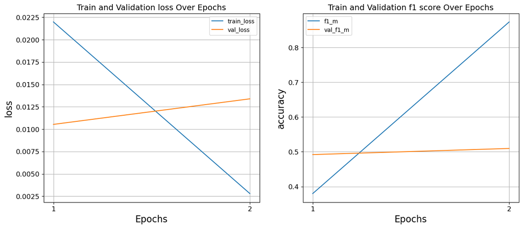

```python
plt.figure(figsize=(15,6))
plt.subplot(1, 2, 1)
plt.plot(history.history["loss"], label="train_loss")
plt.plot(history.history["val_loss"], label="val_loss")
plt.xlabel("Epochs", fontsize=16)
plt.ylabel("loss", fontsize=16)
plt.xticks(np.arange(a), np.arange(1, a+1), fontsize=12)
plt.yticks(fontsize=12)
plt.title("Train and Validation loss Over Epochs", fontsize=14)
plt.legend()
plt.grid()

# plt.show()
plt.subplot(1, 2, 2)
plt.plot(history.history["f1_m"], label="f1_m")
plt.plot(history.history["val_f1_m"], label="val_f1_m")
plt.xlabel("Epochs",fontsize=16)
plt.ylabel("accuracy",fontsize=16)
plt.xticks(np.arange(a), np.arange(1, a+1), fontsize=12)
plt.yticks(fontsize=12)
plt.title("Train and Validation f1 score Over Epochs", fontsize=14)
plt.legend()
plt.grid()
```

#### Évaluation du modèle

```python
_, categorical_acc, f1_m, precision_m, recall_m = shallow_mlp_model.evaluate(test_dataset)
print(f"accuracy on the test set: {round(categorical_acc * 100, 2)}%.")
print(f"f1 on the test set: {round(f1_m * 100, 2)}%.")
print(f"precision on the test set: {round(precision_m * 100, 2)}%.")
print(f"recall on the test set: {round(recall_m * 100, 2)}%.")
```

```
63/63 ━━━━━━━━━━━━━━━━━━━━ 4s 68ms/step - categorical_accuracy: 0.4439 - f1_m: 0.5112 - loss: 0.0132 - precision_m: 0.7037 - recall_m: 0.4057
accuracy on the test set: 45.15%.
f1 on the test set: 50.69%.
precision on the test set: 70.86%.
recall on the test set: 39.82%.
```

#### Inférence avec le modèle

Un petit ensemble de données est utilisé pour montrer comment le modèle fait des prédictions. Pour chaque texte, les labels réels et les labels prédits sont affichés.

```python
model_for_inference = keras.Sequential([text_vectorizer, shallow_mlp_model])

# Create a small dataset just for demoing inference.
inference_dataset = make_dataset(test_df.sample(100), is_train=False)
text_batch, label_batch = next(iter(inference_dataset))
predicted_probabilities = model_for_inference.predict(text_batch)

# Perform inference.
for i, text in enumerate(text_batch[:5]):
    label = label_batch[i].numpy()[None, ...]
    print(f"Abstract: {text[0]}")
    print(f"Label(s): {invert_multi_hot(label[0])}")
    predicted_proba = [proba for proba in predicted_probabilities[i]]
    top_3_labels = [
        x
        for _, x in sorted(
            zip(predicted_probabilities[i], lookup.get_vocabulary()),
            key=lambda pair: pair[0],
            reverse=True,
        )
    ][:3]
    print(f"Predicted Label(s): ({', '.join([label for label in top_3_labels])})")
    print(" ")
```

```
1/1 ━━━━━━━━━━━━━━━━━━━━ 0s 208ms/step
Abstract: b'background invention1 field inventionthe present invention relates light source module including light source optical element mirror2 description related arta light source module video output device light source module used optical pickup device used optical disk drive includes optical e…
Label(s): ['G02B']
Predicted Label(s): (G02B, G03B, F21V)

Abstract: b'technical field present invention relates reaction processing vessels used polymerase chain reactions pcr background art genetic testing widely used examinations wide variety medical fields identification farm products pathogenic microorganisms safety assessment foodproducts even examina…
Label(s): ['G01N' 'B01L']
Predicted Label(s): (B01L, G01N, B62B)

Abstract: b'technical fieldthe present invention relates arc start control method forward reverse feed arc welding forward reverse feed control alternately switching feed speed welding wire forward feed period reverse feed period performed generate short circuit period arc period perform weldingback…
Label(s): ['B23K']
Predicted Label(s): (B23K, G04B, Y02B)

Abstract: b'crossreference related applicationsthis application claims priority chinese patent application 2016112267690 filed state intellectual property office p r china december 27 2016 entire content abovereferenced application incorporated herein referencefieldthe present invention relates tech…
Label(s): ['F16H']
Predicted Label(s): (Y02T, F16H, F16D)

Abstract: b'crossreference related applicationsthe disclosure japanese patent application no2019020844 filed february 7 2019 including specification drawings abstract incorporated herein reference entiretybackgroundthe present disclosure relates semiconductor device example present invention relates…
Label(s): ['G06N']
Predicted Label(s): (G06F, G06N, G11C)
```

### 11- SHAP

```python
pip install shap
```

```python
import shap
```

```python
from sklearn.preprocessing import LabelEncoder
le = LabelEncoder()
all_cpcs = [cpc for sublist in df['CPC_tronc'] for cpc in sublist]
encoded_CPC = le.fit_transform(all_cpcs)
```

```python
encoded_CPC
```

```
array([238,  82,  82, ..., 220, 220, 220], dtype=int64)
```

```python
len(encoded_CPC)
```

```
127878
```

```python
unique_liste = list(set(encoded_CPC))
len(unique_liste)
```

```
604
```

```python
class_names = le.classes_
class_names
```

```
array(['A01B', 'A01C', 'A01D', 'A01F', 'A01G', 'A01H', 'A01J', 'A01K',
       'A01M', 'A01N', 'A01P', 'A21B', 'A21C', 'A21D', 'A22B', 'A22C',
       'A23B', 'A23C', 'A23D', 'A23F', 'A23G', 'A23J', 'A23K', 'A23L',
       'A23N', 'A23P', 'A23V', 'A24B', 'A24C', 'A24D', 'A24F', 'A41B',
       'A41C', 'A41D', 'A41F', 'A41G', 'A41H', 'A42B', 'A43B', 'A43C',
       'A43D', 'A44B', 'A44C', 'A44D', 'A45B', 'A45C', 'A45D', 'A45F',
       'A46B', 'A46D', 'A47B', 'A47C', 'A47D', 'A47F', 'A47G', 'A47H',
       'A47J', 'A47K', 'A47L', 'A61B', 'A61C', 'A61D', 'A61F', 'A61G',
       'A61H', 'A61J', 'A61K', 'A61L', 'A61M', 'A61N', 'A61P', 'A61Q',
       'A62B', 'A62C', 'A62D', 'A63B', 'A63C', 'A63D', 'A63F', 'A63G',
       'A63H', 'A63J', 'B01D', 'B01F', 'B01J', 'B01L', 'B02C', 'B03B',
       'B03C', 'B03D', 'B04B', 'B04C', 'B05B', 'B05C', 'B05D', 'B06B',
       'B07B', 'B07C', 'B08B', 'B09B', 'B09C', 'B21B', 'B21C', 'B21D',
       'B21F', 'B21H', 'B21J', 'B21K', 'B22C', 'B22D', 'B22F', 'B23B',
       'B23C', 'B23D', 'B23F', 'B23G', 'B23H', 'B23K', 'B23P', 'B23Q',
       'B24B', 'B24C', 'B24D', 'B25B', 'B25C', 'B25D', 'B25F', 'B25G',
       'B25H', 'B25J', 'B26B', 'B26D', 'B26F', 'B27B', 'B27C', 'B27D',
       'B27F', 'B27K', 'B27L', 'B27M', 'B27N', 'B28B', 'B28C', 'B28D',
       'B29B', 'B29C', 'B29D', 'B29K', 'B29L', 'B30B', 'B31B', 'B31D',
       'B31F', 'B32B', 'B33Y', 'B41C', 'B41F', 'B41J', 'B41K', 'B41M',
       'B41N', 'B41P', 'B42D', 'B42F', 'B43K', 'B43L', 'B43M', 'B44B',
       'B44C', 'B44F', 'B60B', 'B60C', 'B60D', 'B60F', 'B60G', 'B60H',
       'B60J', 'B60K', 'B60L', 'B60M', 'B60N', 'B60P', 'B60Q', 'B60R',
       'B60S', 'B60T', 'B60W', 'B60Y', 'B61B', 'B61C', 'B61D', 'B61F',
       'B61G', 'B61H', 'B61K', 'B61L', 'B62B', 'B62D', 'B62H', 'B62J',
       'B62K', 'B62L', 'B62M', 'B63B', 'B63C', 'B63G', 'B63H', 'B63J',
       'B64B', 'B64C', 'B64D', 'B64F', 'B64G', 'B64U', 'B65B', 'B65C',
       'B65D', 'B65F', 'B65G', 'B65H', 'B66B', 'B66C', 'B66D', 'B66F',
       'B67B', 'B67C', 'B67D', 'B68C', 'B68G', 'B81B', 'B81C', 'B82Y',
       'C01B', 'C01C', 'C01D', 'C01F', 'C01G', 'C01P', 'C02F', 'C03B',
       'C03C', 'C04B', 'C05B', 'C05C', 'C05D', 'C05F', 'C05G', 'C06B',
       'C07B', 'C07C', 'C07D', 'C07F', 'C07G', 'C07H', 'C07J', 'C07K',
       'C08B', 'C08C', 'C08F', 'C08G', 'C08H', 'C08J', 'C08K', 'C08L',
       'C09B', 'C09C', 'C09D', 'C09F', 'C09G', 'C09J', 'C09K', 'C10B',
       'C10C', 'C10G', 'C10J', 'C10L', 'C10M', 'C10N', 'C11B', 'C11C',
       'C11D', 'C12C', 'C12F', 'C12G', 'C12H', 'C12J', 'C12M', 'C12N',
       'C12P', 'C12Q', 'C12R', 'C12Y', 'C13B', 'C13K', 'C14B', 'C21B',
       'C21C', 'C21D', 'C22B', 'C22C', 'C22F', 'C23C', 'C23F', 'C23G',
       'C25B', 'C25C', 'C25D', 'C25F', 'C30B', 'C40B', 'D01B', 'D01D',
       'D01F', 'D01H', 'D02G', 'D02H', 'D02J', 'D03D', 'D03J', 'D04B',
```

[output cut: 21 more lines]

```
       'G02C', 'G02F', 'G03B', 'G03C', 'G03F', 'G03G', 'G03H', 'G04B',
       'G04C', 'G04F', 'G04G', 'G04R', 'G05B', 'G05D', 'G05F', 'G05G',
       'G06F', 'G06K', 'G06N', 'G06Q', 'G06T', 'G06V', 'G07B', 'G07C',
       'G07D', 'G07F', 'G07G', 'G08B', 'G08C', 'G08G', 'G09B', 'G09C',
       'G09F', 'G09G', 'G10B', 'G10C', 'G10D', 'G10H', 'G10K', 'G10L',
       'G11B', 'G11C', 'G16B', 'G16C', 'G16H', 'G16Y', 'G16Z', 'G21B',
       'G21C', 'G21D', 'G21F', 'G21G', 'G21K', 'H01B', 'H01C', 'H01F',
       'H01G', 'H01H', 'H01J', 'H01L', 'H01M', 'H01P', 'H01Q', 'H01R',
       'H01S', 'H01T', 'H02B', 'H02G', 'H02H', 'H02J', 'H02K', 'H02M',
       'H02N', 'H02P', 'H02S', 'H03B', 'H03C', 'H03D', 'H03F', 'H03G',
       'H03H', 'H03K', 'H03L', 'H03M', 'H04B', 'H04H', 'H04J', 'H04K',
       'H04L', 'H04M', 'H04N', 'H04Q', 'H04R', 'H04S', 'H04T', 'H04W',
       'H05B', 'H05C', 'H05F', 'H05G', 'H05H', 'H05K', 'H10B', 'H10K',
       'H10N', 'Y02A', 'Y02B', 'Y02C', 'Y02D', 'Y02E', 'Y02P', 'Y02T',
       'Y02W', 'Y04S', 'Y10S', 'Y10T'], dtype='<U4')
```

```python
from tensorflow.keras.preprocessing.sequence import pad_sequences
def model_predict(texts):
    # Batch size
    batch_size = 32
    predictions = []

    for i in range(0, len(texts), batch_size):
        text_batch = texts[i:i + batch_size]
        # Vectorisation du texte
        text_vectorized = text_vectorizer(text_batch)
        # Prédiction avec le modèle
        batch_predictions = shallow_mlp_model.predict(text_vectorized)
        predictions.extend(batch_predictions)
        top_3_labels = [
        x
        for _, x in sorted(
            zip(predicted_probabilities[i], lookup.get_vocabulary()),
            key=lambda pair: pair[0],
            reverse=True,
        )
    ][:3]
    return predictions
```

```python
from tensorflow.keras.preprocessing.text import Tokenizer
tokenizer = Tokenizer(filters='!"#$%&()*+,-./:;<=>?@[\]^_`{|}~', lower=True)
masker = shap.maskers.Text(tokenizer=r"\W+")
```

```python
explainer = shap.Explainer(model_predict, masker=masker, output_names=class_names)
explainer
```

```
<shap.explainers._partition.PartitionExplainer at 0x1b35aea1010>
```

```python
example_1 = "feel law states suggestions optimistic beneficial employees specially wish rapidly ramadan said"
example_2 = "however want know something someone causing feel less splendid self step away"
example_3 = "feel pretty pathetic time"
example_4 = "extra money worried time feel beyond pathetic"
example_5 = "really like shop part feel threatened want spend"

examples_new = [example_1, example_2, example_3,example_4, example_5]
examples_new
```

```
['feel law states suggestions optimistic beneficial employees specially wish rapidly ramadan said',
 'however want know something someone causing feel less splendid self step away',
 'feel pretty pathetic time',
 'extra money worried time feel beyond pathetic',
 'really like shop part feel threatened want spend']
```

```python
shap_values = explainer(examples_new)
```

[output not shown]

```
1/1 ━━━━━━━━━━━━━━━━━━━━ 0s 42ms/step
1/1 ━━━━━━━━━━━━━━━━━━━━ 0s 50ms/step
1/1 ━━━━━━━━━━━━━━━━━━━━ 0s 50ms/step
1/1 ━━━━━━━━━━━━━━━━━━━━ 0s 51ms/step
1/1 ━━━━━━━━━━━━━━━━━━━━ 0s 43ms/step
1/1 ━━━━━━━━━━━━━━━━━━━━ 0s 50ms/step
1/1 ━━━━━━━━━━━━━━━━━━━━ 0s 48ms/step
1/1 ━━━━━━━━━━━━━━━━━━━━ 0s 50ms/step
1/1 ━━━━━━━━━━━━━━━━━━━━ 0s 47ms/step
1/1 ━━━━━━━━━━━━━━━━━━━━ 0s 52ms/step
```

```
PartitionExplainer explainer: 6it [00:11,  5.92s/it]
```

```python
print("SHAP Values Shape : {}".format(shap_values.shape))
print("SHAP Base Values  : {}".format(shap_values.base_values))
print("SHAP Data : ")
print(shap_values.data[0])
print(shap_values.data[1])
print(shap_values.data[2])
print(shap_values.data[3])
print(shap_values.data[4])
```

```
SHAP Values Shape : (5, None, 596)
SHAP Base Values  : [[0.45225433 0.47651592 0.47962758 ... 0.4602401  0.45757094 0.46435905]
 [0.45225433 0.47651592 0.47962758 ... 0.4602401  0.45757094 0.46435905]
 [0.45225433 0.47651592 0.47962758 ... 0.4602401  0.45757094 0.46435905]
 [0.45225433 0.47651592 0.47962758 ... 0.4602401  0.45757094 0.46435905]
 [0.45225433 0.47651592 0.47962758 ... 0.4602401  0.45757094 0.46435905]]
SHAP Data :
['feel ' 'law ' 'states ' 'suggestions ' 'optimistic ' 'beneficial '
 'employees ' 'specially ' 'wish ' 'rapidly ' 'ramadan ' 'said']
['however ' 'want ' 'know ' 'something ' 'someone ' 'causing ' 'feel '
 'less ' 'splendid ' 'self ' 'step ' 'away']
['feel ' 'pretty ' 'pathetic ' 'time']
['extra ' 'money ' 'worried ' 'time ' 'feel ' 'beyond ' 'pathetic']
['really ' 'like ' 'shop ' 'part ' 'feel ' 'threatened ' 'want ' 'spend']
```

```python
shap.text_plot(shap_values)
```

[output not shown]